# How replicable is intergroup-contact research?

A multi-method replicability and selective-reporting audit of 21 contact meta-analyses

Published

July 24, 2026

# 1 What this asks

Multiple meta-analyses have aggregated the evidence on intergroup contact and prejudice, generally with positive results. A mean effect, on its own, however, cannot say whether the significant findings behind it would hold up on repetition, nor how much of the published record was filtered to produce them. We therefore ask three questions of key bodies of contact research:

1. **How replicable are the significant findings?** If the significant contact findings in a literature were rerun at their original design and sample size, what share would again be significant? This is *unconditional mean power* (Brunner & Schimmack, 2020), estimated primarily by z-curve 2.0 and cross-checked with p-curve and a maximum-likelihood power estimator (Section 3).
2. **How selectively reported is the record?** How much of the significant record has been *selected for significance* (through publication bias, analytic flexibility, or other questionable research practices)? This is estimated with a Test of Excess Statistical Significance (Askarov et al., 2023; Stanley et al., 2021) and a three-parameter selection model (3PSM) (Hedges & Vevea, 2005) (Section 4).
3. **How big is the effect once selection is corrected?** Where part of a record was filtered, its naive meta-analytic mean is inflated; three bias-adjusted estimators ask what average effect survives the correction (Section 5).

We answer these questions with the full replicability-and-selective-reporting battery from a Stage-1 in-principle-accepted registered report (Wallrich et al., in press). The value of the battery is triangulation: methods that rest on different assumptions either converge on the same verdict for a literature or expose where a single-method reading would have misled.

**ImportantIn brief**

Pooled across **21 contact meta-analyses** (1,891 independent samples in the pooled prejudice/attitude curve once overlapping studies are deduplicated), replicability falls monotonically with experimental control: the estimated replication rate of significant prejudice/attitude effects is **0.85 for cross-sectional surveys, 0.70 for quasi-experiments, 0.63 for field experiments and 0.42 for lab experiments**. Contact *type* barely orders replicability (the types that sit low are those studied almost entirely in brief lab paradigms), and the same ordering recurs when the 21 meta-analyses are audited one at a time.

**Selective reporting is a separate axis:** excess significance concentrates in the experimental and intervention paradigms (imagined, modern lab/field, digital and mediated contact, most extremely Hsieh’s field experiments), while the cleanest records are those deliberately assembled to include unpublished or preregistered work.

**The corrected effect sizes complete the picture:** the mean effects of the accumulated-contact, extended-contact and applied-intervention literatures survive every bias adjustment essentially unchanged, whereas the brief experimental paradigms shrink towards zero. Where selection is suppressed by design, as in Lowe’s preregistered experiments, nothing flags and the average experimental contact effect is simply small (d≈0.1).

**CautionProvisional: based on a limited number of bootstrap iterations**

The registered report runs every method at 5,000 resamples and 5,000 bootstraps. This draft is a development run at reduced counts (300/300 for z-curve, p-curve and ESS; 250/250 for the 3PSM and bias-adjusted estimates; ML power at 20 resamples without a bootstrap CI). This adds Monte-Carlo noise and widens the CIs; every number is provisional pending the final 5,000/5,000 run. Details in Section 8.4.

# 2 The evidence base: 21 meta-analyses

We assembled a **pooled effect-level database** of **21 contact meta-analyses** (every one we could locate that reports per-study data), oriented so that positive effects indicate prejudice *reduction*. Data extraction for every source was validated by reproducing its published pooled estimate. Meta-analyses that report only pooled estimates, with no per-study data, cannot be audited and are listed in Section 12.

Table 1: The 21 contact meta-analyses in the pooled database (original counts, including cross-meta duplicates).

| Meta-analysis | Contact studied | Samples | Effects |
| --- | --- | --- | --- |
| Pettigrew & Tropp (2006) | Foundational survey/quasi/experimental record | 714 | 714 |
| Paolini et al. (2024) | Positive vs. negative contact (valenced) | 236 | 236 |
| Paluck et al. (2021) | Modern contact field and lab experiments | 155 | 508 |
| Reimer & Sengupta (2023) | Contact & collective action (disadvantaged groups) | 114 | 386 |
| Zhou et al. (2019) | Extended contact + cross-group friendship | 95 | 347 |
| Maunder & White (2019) | Contact interventions for mental-health stigma | 109 | 295 |
| da Costa et al. (2024) | Digital / online contact | 91 | 289 |
| Lemmer & Wagner (2015) | Applied field contact interventions | 123 | 123 |
| Miles & Crisp (2014) | Imagined contact (brief experiments) | 71 | 125 |
| Van Assche et al. (2023) | Contact under threat (archival surveys) | 66 | 225 |
| Smith et al. (2009) | Contact & sexual prejudice | 61 | 83 |
| Banas et al. (2020) | Mediated (parasocial/vicarious) contact | 78 | 78 |
| Burnes et al. (2019) | Ageism interventions (contact arms) | 57 | 70 |
| McManus et al. (2021) | Attitudes to intellectual disability | 54 | 131 |
| Apriceno & Levy (2023) | Ageism programs (no per-study N) | 125 | 173 |
| Hsieh et al. (2022) | Real-world prejudice-reduction field experiments | 39 | 53 |
| Lowe (2025) | Preregistered contact experiments (benchmark) | 41 | 41 |
| Rahmani et al. (2025) | Narrative persuasion (intergroup subset) | 22 | 128 |
| Tondok et al. (2024) | Cooperative learning field experiments | 18 | 18 |
| Armstrong et al. (2017) | Disability contact interventions (children) | 9 | 9 |
| Griffiths et al. (2014) | Mental-illness stigma RCTs (contact arms) | 5 | 5 |

*Note.* Two sets of outcomes are excluded from the overall tests of contact–prejudice associations: Reimer & Sengupta’s collective-action intentions, which measure a different outcome from prejudice, and the factual-knowledge-about-ageing measures inside Burnes and Apriceno (only their attitude effects are pooled).

The key estimates for each meta-analysis are tabulated in Section 9. The three questions are taken in turn (Section 3, Section 4, Section 5), and Section 6 assesses case studies of four contrasting literatures. Throughout, field-wide comparisons use each meta-analysis’s full contact sample, while the case studies use narrower, prespecified focal constructions built on each source’s own coding (Section 10 reconciles the two where they differ).

# 3 Question 1: How replicable are the significant findings?

The headline replicability metric is z-curve’s **Expected Replication Rate (ERR)**: the estimated share of a literature’s significant findings that would be significant again if rerun at the original design and sample size. It depends on statistical power, on selection for significance and on the base rate of true hypotheses, and it is estimated from the significant test statistics alone, so it can be computed for any literature regardless of how its record was filtered (see Section 8 for the estimator).

Pooling the 21 meta-analyses and **deduplicating** overlapping samples lets the battery be cut by the variables that should actually drive replicability: research **design** and **contact type**. The main curve covers the prejudice/attitude outcomes. (Section 3.3 shows the same gradient without the pooling or deduplication.)

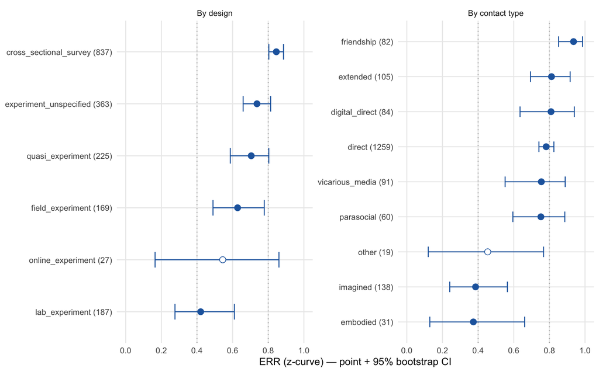

Figure 1: Replicability by research design and contact type (deduplicated pool). Main prejudice/attitude curve only; hollow points are unstable (few significant results).

Table 2: By-stratum battery on the deduplicated pool.

| Level | k | ODR | ERR | EDR | PSSS | ML power | 3PSM ns:+sig |
| --- | --- | --- | --- | --- | --- | --- | --- |
| Design |  |  |  |  |  |  |  |
| cross_sectional_survey | 837 | 0.72 [0.69, 0.76] | 0.85 [0.80, 0.89] | 0.48 [0.29, 0.80] | 0.17 [0.06, 0.26] | 0.84 | 0.38 [0.30, 0.50] |
| experiment_unspecified | 363 | 0.56 [0.51, 0.61] | 0.74 [0.66, 0.81] | 0.41 [0.18, 0.72] | 0.04 [-0.16, 0.18] | — | 0.80 [0.52, 1.20] |
| field_experiment | 169 | 0.39 [0.33, 0.47] | 0.63 [0.49, 0.78] | 0.15 [0.10, 0.59] | 0.13 [0.02, 0.23] | 0.65 | 1.52 [0.74, 2.96] |
| lab_experiment | 187 | 0.47 [0.39, 0.55] | 0.42 [0.28, 0.61] | 0.20 [0.08, 0.47] | 0.18 [0.05, 0.29] | 0.44 | 0.54 [0.22, 1.04] |
| longitudinal_survey | 15 | 0.87 [0.67, 1.00] | — | — | 0.10 [-0.21, 0.38] | 0.92 | 0.25 [0.00, 0.97] |
| online_experiment | 27 | 0.25 [0.11, 0.44] | 0.54 [0.16, 0.86] | 0.11 [0.06, 0.74] | -0.26 [-0.65, 0.13] | 0.59 | 11.63 [0.16, 78.65] |
| quasi_experiment | 225 | 0.48 [0.42, 0.55] | 0.70 [0.59, 0.80] | 0.58 [0.22, 0.74] | 0.00 [-0.12, 0.09] | 0.70 | 1.42 [0.88, 2.34] |
| Contact type |  |  |  |  |  |  |  |
| digital_direct | 84 | 0.56 [0.45, 0.68] | 0.81 [0.64, 0.94] | 0.58 [0.14, 0.93] | 0.14 [-0.04, 0.28] | 0.77 | 0.73 [0.30, 1.89] |
| direct | 1259 | 0.61 [0.58, 0.63] | 0.78 [0.74, 0.83] | 0.43 [0.24, 0.73] | 0.17 [0.10, 0.22] | 0.78 | 0.63 [0.51, 0.80] |
| embodied | 31 | 0.53 [0.35, 0.71] | 0.37 [0.13, 0.66] | 0.19 [0.06, 0.58] | 0.14 [-0.04, 0.36] | 0.41 | 0.42 [0.05, 2.27] |
| extended | 105 | 0.76 [0.67, 0.84] | 0.81 [0.69, 0.92] | 0.61 [0.21, 0.89] | 0.30 [0.04, 0.50] | 0.85 | 0.50 [0.23, 1.08] |
| friendship | 82 | 0.78 [0.68, 0.87] | 0.94 [0.85, 0.99] | 0.91 [0.40, 0.98] | -0.06 [-0.62, 0.31] | 0.91 | 1.41 [0.50, 4.06] |
| imagined | 138 | 0.45 [0.37, 0.55] | 0.39 [0.24, 0.56] | 0.20 [0.07, 0.46] | 0.16 [0.05, 0.27] | 0.41 | 0.59 [0.23, 1.19] |
| other | 19 | 0.42 [0.18, 0.68] | 0.45 [0.12, 0.77] | 0.11 [0.06, 0.57] | 0.24 [-0.03, 0.56] | 0.45 | 0.52 [0.03, 4.05] |
| parasocial | 60 | 0.79 [0.68, 0.88] | 0.75 [0.60, 0.89] | 0.49 [0.14, 0.84] | 0.07 [-0.07, 0.22] | 0.84 | 0.43 [0.14, 1.21] |
| vicarious_media | 91 | 0.47 [0.38, 0.58] | 0.75 [0.55, 0.89] | 0.69 [0.20, 0.88] | 0.21 [0.02, 0.37] | 0.70 | 1.21 [0.38, 2.96] |
| Separate curve |  |  |  |  |  |  |  |
| Collective action (Reimer) | 114 | 0.46 [0.36, 0.55] | 0.69 [0.53, 0.85] | 0.41 [0.11, 0.77] | 0.06 [-0.02, 0.14] | 0.69 | 2.62 [0.91, 9.48] |

Pooled and deduplicated, the primary prejudice/attitude literature has an overall ERR of 0.76 [0.73, 0.80] across 1,891 independent samples. The interest is in how that average splits by design.

**ImportantThe headline finding**

Estimated replication rates of significant prejudice/attitude effects, on the deduplicated pool: **surveys 0.85 → quasi-experiments 0.70 → field experiments 0.63 → lab experiments 0.42**, a clean monotonic gradient over the four classifiable designs. The survey-vs-lab contrast is 0.41 [0.25, 0.58], and the survey-vs-quasi and quasi-vs-lab contrasts also exclude zero; the field-vs-lab estimate points the same way but its interval narrowly includes zero (0.20 [−0.00, 0.40]). This is a gradient in *replicability*, not a ranking of causal validity: the well-identified designs sit at the fragile end precisely because they are hard and expensive to power.

The gradient is read over the four design categories whose degree of experimental control is identifiable, covering 1,418 of the 1,891 samples. The other strata appear in the figure but not on the gradient: *experiment_unspecified* (363 samples, ERR 0.74) pools studies whose design the source coding does not identify, and the online-experiment and longitudinal-survey strata are too small for a stable fit (hollow points). The survey stratum’s place at the top is reinforced by Van Assche’s very large archival surveys, assembled without regard to significance (Section 4 notes a narrow excess-significance flag even there).

## 3.1 Design or contact type?

Contact *type* mostly does not order replicability. Cross-group friendship (ERR 0.94), extended, digital, vicarious-media, direct and parasocial contact all sit near the top of the figure; the two low types are imagined contact (0.39) and embodied/VR contact (0.37). But the extremes track design composition: friendship and extended contact are overwhelmingly survey measures, while imagined and embodied contact are overwhelmingly lab manipulations. The directness of contact does not predict which effects replicate: extended and vicarious contact are as indirect as imagined contact and replicate as well as direct contact does. These are marginal cuts of the same pool, so they cannot isolate contact type from design; what they show is that design orders replicability cleanly while contact type does not.

## 3.3 The pattern recurs across meta-analyses

In addition to the aggregated pool of effects, we can assess each meta-analysis on its own. Given their focus on specific types of contact, this corroborates the results above: the battery is run on each meta-analysis’s *full* contact sample at its own participant-pool unit, with **no cross-meta deduplication**, so every literature is audited exactly as its authors assembled it (the ERR column of the master table in Section 9).

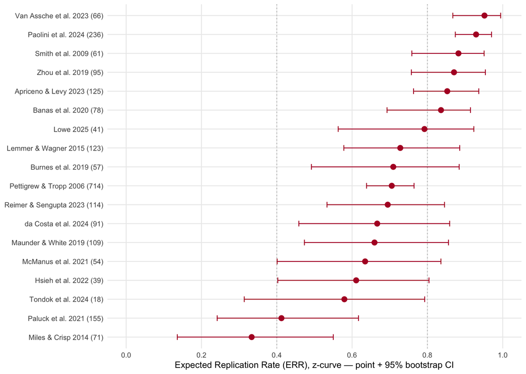

Figure 2: Replicability across 21 contact meta-analyses (full samples). n independent samples in parentheses; dotted lines mark the <sub>0.40/</sub>0.80 rules of thumb. Griffiths, Armstrong and Rahmani have too few significant results for a stable z-curve fit and are omitted.

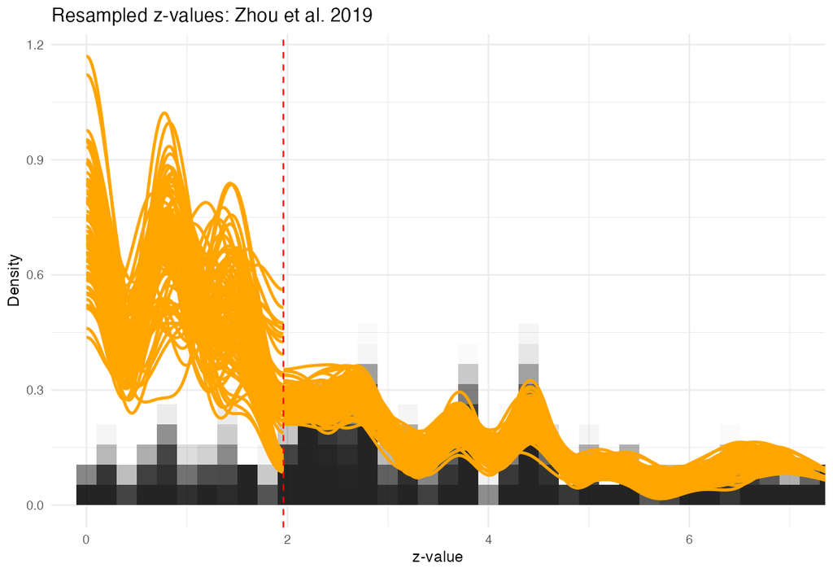

Zhou 2019 — extended contact (highly replicable)

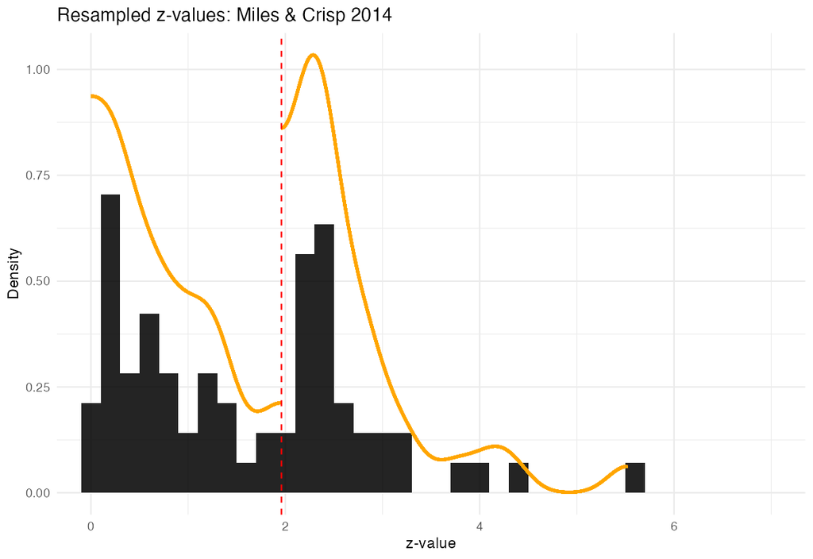

Miles & Crisp 2014 — imagined contact (fragile)

Figure 3: Resampled z-values for the two ends of the range. Each overlays 100 resamples of one independent test per sample; the density is estimated separately either side of z = 1.96 (dashed). A curve that stays high to the right of the line indicates well-powered, replicable evidence.

Maunder & White’s mental-illness-stigma interventions (0.66) sit in the mixed-experimental range alongside the other applied literatures; because their source never coded per-study randomisation, they enter the pooled curve as *experiment_unspecified* rather than on the design gradient.

## 3.4 Do other estimators agree?

The gradient and the weak-end verdict lean on z-curve’s ERR. Two cross-check estimators with different assumptions are therefore run on the same 21 full samples: p-curve and maximum-likelihood (ML) mean power. ML power needs per-study sample sizes, which Apriceno & Levy do not report (it gives standardised effects and their standard errors, but not the per-study *N*), so it is omitted there.

Table 3: Replicability cross-checks on all 21 meta-analyses (full samples, no cross-meta dedup): point estimate [95% bootstrap CI]. ERR is the headline; p-curve and ML power are cross-checks. † = z-curve unstable (not interpreted); ML power is a point estimate without a bootstrap CI in this run, and is not computable for Apriceno & Levy, the one source that reports no per-study N.

| Meta-analysis | ERR | p-curve | ML power (pt) |
| --- | --- | --- | --- |
| Van Assche et al. 2023 | 0.95 [0.87, 0.99] | 0.99 [0.99, 0.99] | 0.95 |
| Paolini et al. 2024 | 0.93 [0.87, 0.97] | 0.99 [0.99, 0.99] | 0.89 |
| Smith et al. 2009 | 0.88 [0.76, 0.95] | 0.99 [0.97, 0.99] | 0.86 |
| Zhou et al. 2019 | 0.87 [0.76, 0.95] | 0.99 [0.99, 0.99] | 0.88 |
| Apriceno & Levy 2023 | 0.85 [0.76, 0.94] | 0.99 [0.99, 0.99] | — |
| Banas et al. 2020 | 0.84 [0.69, 0.91] | 0.98 [0.93, 0.99] | 0.82 |
| Lowe 2025 | 0.79 [0.56, 0.92] | 0.97 [0.69, 0.99] | 0.71 |
| Lemmer & Wagner 2015 | 0.73 [0.58, 0.89] | 0.98 [0.92, 0.99] | 0.77 |
| Burnes et al. 2019 | 0.71 [0.49, 0.88] | 0.93 [0.74, 0.98] | 0.69 |
| Pettigrew & Tropp 2006 | 0.71 [0.64, 0.76] | 0.98 [0.97, 0.99] | 0.74 |
| Reimer & Sengupta 2023 | 0.69 [0.53, 0.85] | 0.98 [0.91, 0.99] | 0.69 |
| da Costa et al. 2024 | 0.67 [0.46, 0.86] | 0.93 [0.78, 0.99] | 0.65 |
| Maunder & White 2019 | 0.66 [0.47, 0.86] | 0.89 [0.72, 0.96] | 0.59 |
| McManus et al. 2021 | 0.63 [0.40, 0.84] | 0.92 [0.68, 0.98] | 0.64 |
| Hsieh et al. 2022 | 0.61 [0.40, 0.80] | 0.98 [0.87, 0.99] | 0.78 |
| Tondok et al. 2024 | 0.58 [0.31, 0.79] | 0.99 [0.81, 0.99] | 0.63 |
| Paluck et al. 2021 | 0.41 [0.24, 0.62] | 0.59 [0.34, 0.80] | 0.41 |
| Miles & Crisp 2014 | 0.33 [0.14, 0.55] | 0.43 [0.13, 0.68] | 0.35 |
| Griffiths et al. 2014† | — | 0.50 [0.05, 0.91] | 0.51 |
| Armstrong et al. 2017† | — | 0.52 [0.09, 0.81] | 0.33 |
| Rahmani et al. 2025† | — | 0.99 [0.69, 0.99] | 0.78 |

Maximum-likelihood mean power tracks ERR across the stable literatures, with Hsieh the one clear divergence (0.78 vs 0.61). p-curve separates the same weak literatures without reproducing the levels: biased upward under effect-size heterogeneity, it sits near the ceiling for every stable literature and collapses only at the weak end (0.59 Paluck, 0.43 Miles). What the estimators agree on is therefore that imagined contact and the modern experiments form the weak end, not the exact ordering or the absolute level. ML power uses the per-study sample sizes that z-curve ignores, so its agreement is some corroboration that the weak-end verdict does not depend on the z-curve model; but it shares z-curve’s methodological lineage rather than offering a fully independent check.

# 4 Question 2: How selectively reported is the record?

Replicability asks whether the *significant* findings would hold up; selective reporting asks how much of the *record* was filtered to produce them. The battery estimates both precisely because they can disagree; in the contact literature they do. The selective-reporting metrics work by comparing what a literature reports against what its power could produce: **PSSS** estimates the proportion of significant results that exist *because* they were significant (a conservative lower bound), the one-tailed **TESS/PSST** statistics test whether the excess of significant results is too large to dismiss (flagged above 1.645), and the **3PSM** estimates the relative publication odds of a non-significant versus a positive-significant result (Section 8.2 for full definitions).

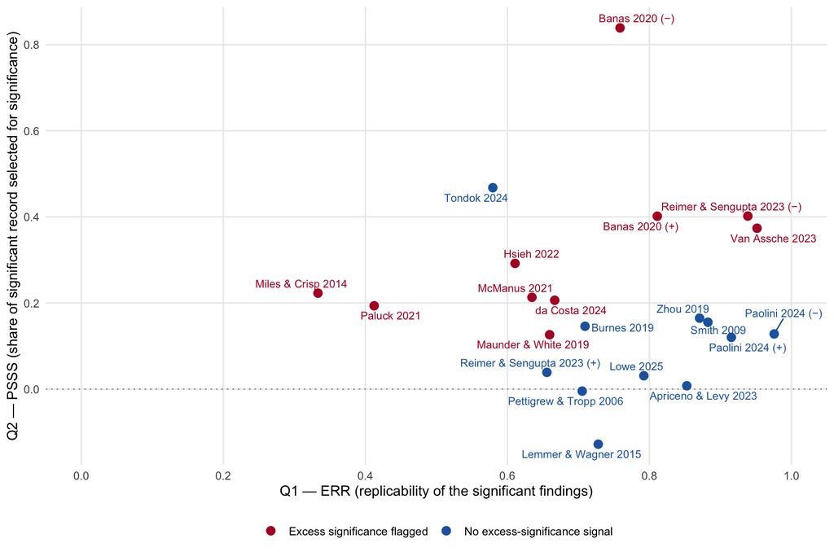

Figure 4: Replicability and selective reporting are separate axes. Per-literature point estimates (full samples; Paolini, Banas and Reimer as valence-split subsets). Red: excess significance flagged (TESS or PSST > 1.645). Unstable z-curves excluded.

The figure carries the section’s central claim: the two axes are close to independent. Every combination occurs: highly replicable and clean (Pettigrew & Tropp, both of Paolini’s valence subsets), highly replicable yet flagged (Van Assche, Banas’s positive-contact subset), moderately replicable with the strongest selection signature in the set (Hsieh), and fragile with clear selection (Miles’s imagined contact). Hsieh’s field experiments pair a moderate ERR (0.61 on its full sample) with 76% of tests significant against an expected discovery rate of 0.13. On its narrower extended-contact-only focal construction, Zhou pairs the highest replicability (ERR 0.82) with the largest PSSS (0.38 [0.02, 0.62]). On its full sample the excess-significance signal does not reach significance (PSSS 0.16 [−0.28, 0.48]), but on the focal construction both test statistics clear the threshold (PSST 2.38, TESS 2.73). The PSSS interval is wide and only just excludes zero, but by the pre-specified rule this near-top-replicability literature registers selection. A single replicability index would miss all of this: it takes the excess-significance and selection-model methods to show that even well-replicating corners of the contact literature sit on a filtered evidence base.

Where, then, is the record most filtered? The strongest excess-significance signals cluster in the experimental and intervention paradigms — imagined contact, Paluck’s modern experiments, Hsieh’s field experiments, digital contact and mediated contact, with Hsieh the extreme (exact statistics in the table below). Weaker signals are not confined to the experiments, however: Van Assche’s archival surveys, McManus’s intellectual-disability studies and Armstrong’s small nine-study record also cross the threshold, and Maunder flags on PSST. These borderline statistics are weaker evidence than the concentrated signals above, so the pattern is a matter of degree rather than a clean experimental/correlational divide. In the deduplicated pool the overall signal is modest but non-zero (PSSS 0.14 [0.08, 0.20]).

Run on the pooled curve directly, the 3PSM agrees: a non-significant result carries 0.59 [0.49, 0.71] the publication odds of a positive-significant one. Broken out by design and contact type (Table 2), the selection signal is not confined to the experiments — it is if anything clearest where replicability is highest. The cross-sectional surveys carry a positive excess-significance signal (PSSS 0.17 [0.06, 0.26]) and the pool’s sharpest 3PSM signature (0.38 [0.30, 0.50]), with the lab experiments similar on PSSS (0.18 [0.05, 0.29]) but noisier on the 3PSM; the field- and quasi-experimental strata show no 3PSM selection (odds above one, intervals spanning it). That the most replicable design also carries the clearest pooled selection signature restates the section’s theme in one curve: replicability and selective reporting are separate axes.

Table 4: Selective-reporting statistics per meta-analysis.

| Meta-analysis | k | ODR | EDR | PSSS | TESS | PSST | 3PSM ns:+sig |
| --- | --- | --- | --- | --- | --- | --- | --- |
| Paluck et al. 2021 | 155 | 0.47 [0.37, 0.56] | 0.18 [0.07, 0.51] | 0.19 [0.09, 0.31] | 4.52 [0.65, 8.98] | 3.41 [1.61, 5.52] | 0.59 [0.22, 1.27] |
| da Costa et al. 2024 | 91 | 0.55 [0.44, 0.66] | 0.41 [0.10, 0.80] | 0.21 [0.05, 0.35] | 4.22 [-0.69, 8.79] | 3.08 [0.69, 5.39] | 0.53 [0.19, 1.41] |
| Miles & Crisp 2014 | 71 | 0.47 [0.35, 0.59] | 0.22 [0.07, 0.52] | 0.22 [0.11, 0.36] | 4.22 [1.23, 7.64] | 2.97 [1.52, 4.48] | 0.29 [0.03, 0.80] |
| Hsieh et al. 2022 | 39 | 0.76 [0.60, 0.90] | 0.13 [0.09, 0.43] | 0.29 [0.11, 0.48] | 4.18 [0.64, 7.69] | 2.60 [0.92, 4.35] | 0.19 [0.03, 0.65] |
| Banas et al. 2020 | 78 | 0.81 [0.72, 0.90] | 0.79 [0.27, 0.91] | 0.18 [0.06, 0.33] | 2.78 [-0.37, 6.52] | 2.19 [0.73, 4.03] | 0.30 [0.11, 0.79] |
| Armstrong et al. 2017† | 9 | 0.56 [0.22, 0.89] | — | 0.35 [-0.09, 0.78] | 2.64 [-1.60, 5.68] | 1.56 [-0.46, 2.86] | 0.19 [0.03, 4.81] |
| McManus et al. 2021 | 54 | 0.59 [0.43, 0.74] | 0.30 [0.10, 0.75] | 0.21 [-0.12, 0.45] | 2.40 [-3.72, 6.96] | 1.80 [-0.89, 4.08] | 0.68 [0.21, 2.51] |
| Van Assche et al. 2023 | 66 | 0.96 [0.89, 1.00] | 0.78 [0.32, 0.99] | 0.37 [-0.04, 0.68] | 1.90 [-2.15, 5.50] | 1.85 [-0.17, 3.44] | 0.09 [0.00, 0.36] |
| Maunder & White 2019 | 109 | 0.43 [0.32, 0.52] | 0.58 [0.17, 0.84] | 0.13 [-0.07, 0.26] | 1.64 [-4.17, 6.54] | 1.87 [-0.80, 4.33] | 1.50 [0.64, 3.19] |
| Burnes et al. 2019 | 57 | 0.55 [0.42, 0.70] | 0.36 [0.11, 0.87] | 0.15 [-0.01, 0.33] | 1.33 [-1.86, 4.70] | 1.37 [-0.06, 2.84] | 0.38 [0.12, 1.01] |
| Tondok et al. 2024 | 18 | 0.89 [0.72, 1.00] | 0.12 [0.07, 0.43] | 0.47 [-0.41, 1.00] | 0.93 [-2.36, 4.24] | 1.02 [-0.84, 2.56] | 0.20 [0.00, 2.37] |
| Reimer & Sengupta 2023 | 114 | 0.46 [0.36, 0.55] | 0.41 [0.11, 0.77] | 0.06 [-0.02, 0.14] | 0.10 [-3.34, 4.06] | 2.09 [-0.64, 7.50] | 2.62 [0.91, 9.48] |
| Griffiths et al. 2014† | 5 | 0.40 [0.00, 0.80] | — | 0.05 [-0.21, 0.55] | -0.19 [-1.83, 2.45] | 0.14 [-0.66, 1.40] | 0.58 [0.04, 98.80] |
| Smith et al. 2009 | 61 | 0.77 [0.66, 0.87] | 0.73 [0.26, 0.94] | 0.16 [-0.28, 0.43] | -0.25 [-3.94, 2.68] | 0.75 [-1.19, 2.15] | 0.97 [0.39, 2.36] |
| Zhou et al. 2019 | 95 | 0.79 [0.69, 0.87] | 0.77 [0.27, 0.95] | 0.16 [-0.28, 0.48] | -0.28 [-4.89, 4.67] | 0.96 [-1.42, 3.18] | 0.87 [0.29, 2.08] |
| Lowe 2025 | 41 | 0.39 [0.27, 0.54] | 0.28 [0.12, 0.92] | 0.03 [-0.18, 0.22] | -0.87 [-4.27, 3.00] | 0.27 [-1.23, 2.21] | 1.79 [0.54, 5.30] |
| Apriceno & Levy 2023 | 125 | 0.74 [0.66, 0.81] | 0.34 [0.20, 0.91] | 0.01 [-0.67, 0.28] | -2.29 [-11.72, 4.88] | 0.11 [-4.47, 3.25] | 0.44 [0.23, 0.91] |
| Paolini et al. 2024 | 236 | 0.86 [0.81, 0.90] | 0.81 [0.38, 0.97] | 0.03 [-0.18, 0.21] | -2.44 [-9.79, 6.05] | 0.48 [-2.75, 4.46] | 0.27 [0.16, 0.39] |
| Rahmani et al. 2025† | 22 | 0.32 [0.09, 0.55] | — | -0.13 [-0.47, 0.16] | -2.69 [-6.46, 1.19] | -0.72 [-2.42, 1.01] | 5.54 [0.37, 99.20] |
| Lemmer & Wagner 2015 | 123 | 0.36 [0.28, 0.44] | 0.39 [0.13, 0.82] | -0.13 [-0.26, -0.02] | -6.25 [-9.40, -3.26] | -1.63 [-3.00, -0.33] | 1.96 [1.23, 3.49] |
| Pettigrew & Tropp 2006 | 714 | 0.56 [0.52, 0.59] | 0.39 [0.17, 0.66] | -0.00 [-0.09, 0.11] | -6.39 [-10.92, 0.22] | -0.11 [-2.10, 2.77] | 1.07 [0.76, 1.39] |

Because Paolini’s, Banas’s and Reimer’s records each mix positively and negatively valenced contact (whose hypothesised directions oppose), their direction-dependent statistics come from valence-split subsets, each oriented to its own hypothesis (`replicability_engine/run_valence_splits.R`; the oriented means reproduce the published per-valence pooled estimates). The split sharpens both verdicts: Paolini is clean in both halves and both means survive correction (Section 5), while Banas’s signal, diluted in the pooled mixture, strengthens on both sides (positive contact PSSS 0.40 [0.10, 0.63]; the small negative-contact subset 0.84 [0.31, 1.00]). Mediated contact thereby joins Hsieh as a literature that replicates reasonably well on a visibly filtered record. Reimer & Sengupta’s collective-action record splits the same way: its positive-contact studies — the “ironic”/sedative effect the paper is built on — show no selection signal (PSSS 0.04 [−0.18, 0.21], neither excess-significance statistic clearing the threshold), whereas its small negative-contact subset (31 samples) flags strongly (PSST 5.14); with so few samples, several of them very large surveys, that signal is best read as suggestive rather than diagnostic.

The clean end is anchored by exactly the records built to include unpublished work. Lemmer & Wagner’s PSSS is significantly *negative* (−0.13 [−0.26, −0.02]), and its 3PSM puts the publication odds of a non-significant result at roughly twice those of a positive-significant one, a pattern compatible with a literature built on dissertations and unpublished interventions, though not diagnostic of it. Pettigrew & Tropp’s PSSS is essentially zero (−0.00 [−0.09, 0.11]) with 3PSM odds near parity (1.07), consistent with a meta-analysis that deliberately gathered unpublished work. None of Paolini, Zhou, Smith, Apriceno or Lowe shows a positive excess-significance signal on their full samples. Because PSSS is a conservative lower bound, a near-zero value means excess significance was not *detected*: it does not bound selection from above. The clean end is therefore “no selection detected”, not proof of its absence.

# 5 Question 3: How big is the effect once selection is corrected?

If a literature has been selected for significance, its naive meta-analytic mean is inflated, so the third question is what average effect survives once selection is corrected: which contact conclusions stand, which weaken, and which disappear. Three adjustment strategies with different assumptions are compared against the naive random-effects estimate, each on the dataset’s own effect-size scale: trim-and-fill (Duval & Tweedie, 2000), included because several of the original meta-analyses relied on it as their bias check; PET-PEESE (Stanley & Doucouliagos, 2014), a regression-based correction using the effect–SE relationship; and the 3PSM-adjusted mean, the mean effect implied by the selection model. Trim-and-fill detects funnel asymmetry rather than p-value selection, and here it fails as a bias check: it trims Pettigrew & Tropp, where nothing flags, more than it moves Hsieh, the strongest-selected record in the audit, so passing it is weak reassurance.

Run on the pooled prejudice/attitude curve, every correction pulls the naive mean down, and the corrections that target p-value selection pull it furthest: the naive random-effects mean of 0.23 falls to 0.21 under PET-PEESE and to 0.11 under the 3PSM, with trim-and-fill the most aggressive at 0.09. Broken out by design (Table 5), the shrinkage tracks the selection signal from Section 4: the cross-sectional surveys, which carry the clearest pooled selection signature, shrink the most (naive 0.18 to 0.01 under the 3PSM), while the field- and quasi-experimental strata, where no selection was detected, barely move. The pooled mean mixes correlation-based (Fisher z) and SMD-based (*d*/*g*) sources on one axis, so its absolute value is a rough scale-blend rather than a single interpretable effect size; the informative quantity is the *relative* shrinkage across corrections and strata, not the pooled number itself.

Table 5: Naive vs bias-adjusted mean effects on the pooled prejudice curve, overall and by design.

| Stratum | Random effects | Trim-and-fill | PET-PEESE | 3PSM-adjusted |
| --- | --- | --- | --- | --- |
| OVERALL | 0.23 [0.21, 0.24] | 0.09 [0.07, 0.11] | 0.21 [0.17, 0.23] | 0.11 [0.05, 0.16] |
| cross_sectional_survey | 0.18 [0.16, 0.20] | 0.07 [0.05, 0.09] | 0.15 [0.12, 0.17] | 0.01 [-0.04, 0.07] |
| quasi_experiment | 0.27 [0.23, 0.30] | 0.27 [0.13, 0.36] | 0.25 [0.21, 0.29] | 0.31 [0.26, 0.37] |
| field_experiment | 0.25 [0.19, 0.32] | 0.24 [0.10, 0.30] | 0.23 [0.17, 0.30] | 0.22 [0.07, 0.39] |
| lab_experiment | 0.38 [0.32, 0.45] | 0.24 [0.19, 0.40] | 0.12 [-0.17, 0.43] | 0.27 [0.15, 0.38] |
| online_experiment | 0.24 [0.07, 0.43] | 0.28 [0.06, 0.56] | 0.14 [-0.57, 0.72] | 0.67 [0.04, 1.29] |
| experiment_unspecified | 0.33 [0.27, 0.40] | 0.17 [0.03, 0.39] | 0.23 [0.02, 0.31] | 0.18 [-0.07, 0.35] |
| longitudinal_survey | -0.04 [-0.19, 0.14] | -0.04 [-0.19, 0.14] | -0.07 [-0.42, 0.18] | -0.07 [-0.26, 0.13] |

Point [95% bootstrap CI]. Values blend Fisher-z (correlation-based) and d/g (SMD-based) sources, so absolute magnitudes are a scale mixture; read the shrinkage across columns, not the level. The 3PSM-adjusted mean is erratic for small strata under its one-sided fallback (online_experiment).

Table 6: Naive vs bias-adjusted mean effects.

| Meta-analysis | Scale | Random effects | Trim-and-fill | PET-PEESE | 3PSM-adjusted |
| --- | --- | --- | --- | --- | --- |
| McManus et al. 2021 | d | 0.71 [0.50, 0.91] | 0.60 [0.26, 0.86] | 0.29 [-0.14, 0.75] | 0.62 [0.23, 1.03] |
| Smith et al. 2009 | d | 0.56 [0.48, 0.65] | 0.56 [0.47, 0.67] | 0.49 [0.38, 0.62] | 0.56 [0.46, 0.66] |
| Armstrong et al. 2017 | d | 0.44 [0.18, 0.75] | 0.20 [0.16, 0.65] | -0.01 [-0.66, 0.22] | 0.24 [0.12, 0.66] |
| Rahmani et al. 2025 | d | 0.42 [0.14, 0.84] | 0.46 [0.12, 0.86] | 0.42 [0.06, 0.84] | 0.68 [0.12, 1.38] |
| Maunder & White 2019 | d | 0.41 [0.33, 0.53] | 0.40 [0.21, 0.51] | 0.06 [-0.16, 0.33] | 0.45 [0.28, 0.65] |
| Paolini et al. 2024 — negative contact | Fisher z\* | 0.39 [0.35, 0.44] | 0.33 [0.30, 0.42] | 0.38 [0.31, 0.45] | 0.36 [0.24, 0.43] |
| Paluck et al. 2021 | d | 0.36 [0.28, 0.43] | 0.22 [0.16, 0.39] | -0.13 [-0.36, 0.07] | 0.28 [0.16, 0.42] |
| Miles & Crisp 2014 | d | 0.36 [0.25, 0.45] | 0.21 [0.14, 0.31] | -0.36 [-0.63, -0.13] | 0.18 [0.01, 0.34] |
| Burnes et al. 2019 | d | 0.35 [0.18, 0.53] | 0.29 [-0.02, 0.49] | 0.41 [-0.22, 0.75] | -0.36 [-1.38, 0.47] |
| Griffiths et al. 2014 | d | 0.33 [0.12, 0.52] | 0.33 [0.12, 0.57] | 1.78 [-2.18, 8.35] | 0.29 [0.07, 0.55] |
| Lemmer & Wagner 2015 | g | 0.33 [0.27, 0.38] | 0.39 [0.30, 0.44] | 0.35 [0.28, 0.42] | 0.39 [0.31, 0.48] |
| Banas et al. 2020 — negative contact | Fisher z\* | 0.32 [0.25, 0.42] | 0.32 [0.23, 0.42] | 0.21 [0.06, 0.37] | -0.26 [-16.12, 0.29] |
| Tondok et al. 2024 | g | 0.32 [0.25, 0.39] | 0.32 [0.24, 0.39] | 0.28 [0.01, 0.39] | 0.24 [-0.79, 0.39] |
| Zhou et al. 2019 | Fisher z | 0.27 [0.23, 0.31] | 0.30 [0.23, 0.35] | 0.30 [0.24, 0.35] | 0.26 [0.20, 0.31] |
| Apriceno & Levy 2023 | g | 0.25 [0.13, 0.37] | 0.32 [0.11, 0.55] | 0.34 [0.20, 0.46] | -0.28 [-0.85, 0.14] |
| da Costa et al. 2024 | g (reduction = +) | 0.24 [0.13, 0.36] | 0.09 [-0.02, 0.35] | 0.07 [-0.15, 0.32] | 0.12 [-0.27, 0.35] |
| Banas et al. 2020 — positive contact | Fisher z | 0.23 [0.17, 0.28] | 0.15 [0.11, 0.26] | 0.07 [-0.05, 0.22] | 0.18 [0.10, 0.27] |
| Paolini et al. 2024 — positive contact | Fisher z | 0.23 [0.19, 0.28] | 0.13 [0.10, 0.29] | 0.23 [0.18, 0.30] | 0.10 [-0.04, 0.22] |
| Hsieh et al. 2022 | d | 0.22 [-0.04, 0.46] | 0.17 [-0.05, 0.45] | 0.25 [-0.36, 0.72] | -0.17 [-0.62, 0.33] |
| Pettigrew & Tropp 2006 | Fisher z | 0.21 [0.20, 0.22] | 0.15 [0.13, 0.22] | 0.20 [0.18, 0.21] | 0.22 [0.19, 0.23] |
| Van Assche et al. 2023 | Fisher z | 0.21 [0.14, 0.29] | 0.17 [0.09, 0.27] | 0.20 [0.04, 0.30] | 0.04 [-0.15, 0.24] |
| Reimer & Sengupta 2023 — negative contact (mobilising) | Fisher z | 0.14 [0.08, 0.23] | 0.10 [0.02, 0.21] | 0.01 [-0.08, 0.14] | 0.17 [-0.02, 0.30] |
| Lowe 2025 | std. effect | 0.11 [0.06, 0.16] | 0.11 [0.04, 0.19] | 0.10 [-0.01, 0.16] | 0.14 [0.05, 0.21] |
| Reimer & Sengupta 2023 — positive contact (ironic) | Fisher z | 0.06 [0.03, 0.09] | 0.06 [0.01, 0.10] | 0.05 [0.00, 0.09] | 0.04 [-0.03, 0.11] |

Point [95% bootstrap CI], each on the dataset's native scale (positive = the effect's hypothesised direction). CIs reflect the resample-then-bootstrap dependence handling, not the models' internal SEs.  
Paolini, Banas and Reimer enter as valence-split subsets (* negative contact: more prejudice = positive; for Reimer, positive = the subset's own hypothesis — the ironic/sedative effect for positive contact, the mobilising effect for negative contact).

**Where no selection was detected, the conclusions survive, and some strengthen.** The accumulated-contact, extended-contact and applied-intervention literatures change little under any correction: Pettigrew & Tropp’s naive mean of 0.21 (Fisher z, matching the published pooled r = −.21) holds at 0.15–0.22 across the corrections, and Zhou, Smith and both of Paolini’s valence halves behave the same way (table above). Reimer & Sengupta’s “ironic” effect behaves the same way: its positive-contact mean (Fisher z 0.06, matching the published r = −.07) is a small sedative association that no correction meaningfully moves — a small effect, but a robust one. Lemmer & Wagner’s adjustments go *up*, as expected for a literature whose excess-significance statistics are negative, and Lowe’s preregistered estimate stays small under every method. The evidence the contact hypothesis chiefly rests on therefore does not depend on trusting the uncorrected means, nor on believing any particular bias model.

**Where selection was flagged, the corrections bite, and one conclusion disappears.** Miles & Crisp’s naive d = 0.36 falls to 0.21 under trim-and-fill and 0.18 under the 3PSM, and Paluck and Banas’s positive-contact subset shrink similarly (table above). The clearest reversal is digital contact: da Costa’s 0.24 shrinks under all three corrections to estimates whose CIs all span zero. PET-PEESE goes further for the two weakest literatures, flipping Miles and Paluck negative, better read as “no evidence of a non-zero mean” than as genuinely negative effects.

**Where selection is extreme or the record small, no single corrected value can be trusted.** The 3PSM-adjusted mean turns erratic wherever its one-sided fallback meets a small or approximate record, flipping Hsieh, Burnes, Apriceno and Banas’s 26-sample negative-contact subset to implausible values (table above). Reimer’s 31-sample negative-contact subset is the same story: its random-effects mean (Fisher z 0.14) reproduces the published mobilising association, but PET-PEESE and the 3PSM pull it in opposite directions (0.01 vs 0.17), so no single corrected value is trustworthy. The mapping from diagnostics to adjustments is not one-to-one either: Zhou’s focal set flags selection yet its mean barely moves, while Hsieh’s corrections point in opposite directions. For those sources the defensible conclusion is uncertainty, not any single corrected estimate.

**Why trim-and-fill is the least reliable of the three.** Its imputation count is unstable near funnel symmetry, which is exactly where it does most of its damage. For Pettigrew & Tropp — clean on every other index — the bootstrap distribution of the number of imputed studies is bimodal: trim-and-fill imputes nothing in 43% of resamples and a large number in the rest, so its point estimate is dragged down despite no selection signal. On the pooled curve it imputes studies in effectively every resample (mean 477.5 filled points; k0 = 0 in 0% of bootstraps), pulling the pooled mean well below the selection-model and PET-PEESE corrections — a clean literature over-trimmed. This instability is a property of trim-and-fill itself, not of the moment estimator used to fit it: on the full, un-resampled data the REML and DerSimonian–Laird estimators impute near-identical numbers of studies (Table 7), so the DerSimonian–Laird estimator adopted throughout for tractability (Section 8.4) leaves every trim-and-fill verdict unchanged.

Table 7: Trim-and-fill sensitivity to the moment estimator: imputed studies (k0) on the full data, REML vs DerSimonian–Laird.

| Dataset | k | REML k0 | DL k0 |
| --- | --- | --- | --- |
| Prejudice/attitudes (pooled) | 3178 | — | 755 |
| Pettigrew & Tropp 2006 | 714 | 161 | 163 |
| da Costa et al. 2024 | 289 | 52 | 51 |
| Miles & Crisp 2014 | 125 | 29 | 29 |
| Hsieh et al. 2022 | 53 | 6 | 6 |

Imputed-study count on the full (un-resampled) effect set. REML is not computed for the pool (its iterative refit is the run-time bottleneck the DL estimator avoids); elsewhere the two estimators agree to within two studies.

# 6 Four case studies: the three questions in action

The three questions so far describe the whole field; the case studies show what their combinations look like from inside a single literature. The four occupy distinct positions in the replicability × selection space of Section 4: **Pettigrew & Tropp** is replicable and clean (and contains the design gradient *within* a single meta-analysis), **imagined contact** is fragile and selected, **Hsieh’s field experiments** are moderately replicable but extremely selected, and **Lowe’s preregistered experiments** suppress selection by design. Each case answers the three questions in turn, from the battery run on its focal construction (Section 10).

## 6.1 Pettigrew & Tropp (2006): the foundational record, and the gradient in miniature

On replicability, the design gradient runs *within* the meta-analysis the contact hypothesis rests on: survey and field studies of accumulated contact (ERR 0.76) are more replicable than quasi-experiments (0.60), a difference of 0.15 [0.03, 0.30] that excludes zero, with pure experiments falling further to 0.51 (too few, *n* = 36, to separate cleanly). Because this contrast compares designs inside one meta-analysis (same inclusion rules, same coding, same era), it rules out the source-level differences that could confound the pooled gradient. Design remains entangled with setting, sample size and contact paradigm even within the record, but of the evidence here it comes closest to isolating design itself.

On selective reporting, the record shows no sign of selection on any indicator: PSSS −0.00 [−0.10, 0.09], and the 3PSM puts non-significant and positive-significant results at almost equal publication odds (1.07 [0.81, 1.37]), consistent with its deliberate inclusion of unpublished studies. Its published and unpublished effects do not differ in replicability (ERR 0.69 vs 0.75) and both show essentially zero selection (PSSS −0.00 vs −0.06), so there is no sign that the published record is inflated relative to the file drawer. The corrected effect follows suit: the naive mean (Fisher z 0.21, matching the published pooled r = −.21) holds at 0.20–0.22 under PET-PEESE and the 3PSM.

## 6.2 Imagined contact (Miles & Crisp 2014): the fragile extreme

Imagined contact has the lowest stable estimated replicability in the audit (ERR 0.28 [0.13, 0.51] on its 71-experiment focal construction), in the range of literatures that fared badly in large replication projects and consistent with its small two-cell designs. Every estimator agrees: p-curve (0.44) and ML power (0.34) place it just as low, so the weakness is genuine underpowering, not an artefact of z-curve’s model. It also carries a clear selection signature (PSSS 0.22 [0.11, 0.33], TESS 4.0), and its bias-adjusted mean shrinks accordingly: the naive d = 0.34 falls to 0.21 under trim-and-fill and 0.18 under the 3PSM. PET-PEESE flips negative (−0.30), a known behaviour of that method under heterogeneity and small *k* (Section 5).

The theoretical point comes from the comparison with the other indirect forms: extended and vicarious contact are just as indirect and replicate as well as direct contact, so the marginal pattern implicates the brief lab paradigm far more strongly than indirectness. As with the pooled cut, though, the two are not experimentally separable here.

## 6.4 Lowe (2025): the selection-resistant benchmark

Lowe’s meta-analysis of preregistered contact experiments is the natural control on everything above, because its design suppresses the two routes to selection the battery is built to detect. Its studies are drawn from the AEA, EGAP and OSF registries, so registered nulls are retrieved whether or not they were published; and each effect is read off a preregistered primary outcome, which blocks within-study outcome selection. They cannot, though, guarantee complete registration, adherence and retrieval.

**ImportantRead Lowe’s evidence directly, not through z-curve**

On the 25 clean experiments of the case-study focal set, a random draw of one effect per experiment leaves only ~7 significant tests, so the z-curve fit is unstable and its ERR should not be read (the bootstrap CIs are flagged; on the full 41-effect sample it is estimable at 0.79). The scarcity of significant results makes z-curve uninformative, but does not by itself demonstrate suppressed selection. The case for selection resistance rests on the design (registry-based retrieval, preregistered outcomes) together with the absence of any positive selection signal; the informative evidence is direct: a low discovery rate and a small mean effect.

The rest of the battery, which runs in full on Lowe’s effect-level data, confirms the direct reading: no selection indicator reaches significance (PSSS 0.12 [−0.06, 0.28], PSST 1.54), and the mean effect sits at 0.03–0.10 under the naive and every bias-adjusted estimator alike, with all CIs spanning zero. This is the mirror image of imagined contact: where selection is possible, the significant effects are unreliable; where it is suppressed by design, the average experimental contact effect is simply small.

# 7 What it adds up to

Replicability in intergroup-contact research is ordered by research design. On the deduplicated pool of 21 meta-analyses, the estimated replication rate of significant prejudice/attitude effects falls monotonically with experimental control, halving from the cross-sectional surveys (0.85) to the lab experiments (0.42). What makes the gradient credible is its recurrence: it is echoed when the 21 literatures are audited one at a time, it holds within the foundational Pettigrew & Tropp record itself, and the verdict on the weak end does not depend on the z-curve model, since p-curve and ML power also place imagined contact and the modern experiments lowest. Contact *type* does not order replicability on its own (extended and vicarious contact are as indirect as imagined contact and replicate as well as direct contact), though the marginal cuts here cannot fully separate type from the designs each type is studied with.

Selective reporting is a second, separate story. The strongest excess significance sits in the experimental and intervention paradigms (most extremely in Hsieh’s field experiments, which report significance far above what their power can support), with weaker signals crossing the threshold in a few correlational and applied records too, and it can coexist with high replicability, as extended contact shows. The clean end is anchored by the literatures assembled to include unpublished work. A replicable literature, in other words, is not automatically an unfiltered one; the two verdicts have to be read together.

Correcting for that filtering translates the pattern into effect sizes. The core evidence for intergroup contact survives: accumulated real-world contact measured in surveys and field studies, extended contact and applied field interventions have estimated replication rates in the range where significant findings are expected to hold up, and their mean effects are essentially unchanged under every bias adjustment. Digital contact is the instructive counterexample: it replicates moderately (ERR 0.67), but it carries a clear excess-significance signal and its adjusted mean shrinks to values indistinguishable from zero (Section 5). The fragility is localised and predictable: it lives in the brief experimental paradigms, above all imagined contact (ERR ~0.3, with a clear selection signature and adjusted means one-third to one-half smaller), with the broader modern experiments not far behind. And where selection is suppressed by design, in Lowe’s preregistered experiments, no indicator flags and the average experimental contact effect is simply small (a standardised effect of around 0.1 under every estimator; Section 6.4). On this evidence the contact hypothesis is carried by the observational and applied literatures (accumulated survey contact, extended contact, real-world interventions) more than by the brief experiments that are easiest to run and easiest to over-read.

**ImportantReplicable does not mean causal**

The gradient runs the wrong way for causal inference: the designs that replicate best identify contact effects worst. High survey-literature ERR partly reflects the reproducibility of stable individual-differences correlations and shared-method variance in large samples; it speaks to the replicability of the *evidence*, not to causal identification. The audit’s conclusion is about which bodies of evidence would hold up on repetition, not that surveys establish, better than experiments do, that contact causes prejudice reduction.

# 8 The battery: methods in full

The engine (`replicability_engine/engine.R`) runs the registered report’s own analysis code (Wallrich et al., in press), wrapped in the same resample-then-bootstrap dependence handling. The *approach* — the choice of methods and how they are combined — was prespecified and accepted at Stage-1 review for IWO psychology. That acceptance covers the battery itself; its application to contact data here, including the adaptations in Section 8.4 and the bias-adjusted estimators, is our own and is not underwritten by the Stage-1 decision.

## 8.1 Replicability: mean power

**z-curve 2.0** (Bartoš & Schimmack, 2022) fits a finite mixture of non-central distributions to the *significant* z-values (a selected literature cannot be fit on its full set of results), then extrapolates to the non-significant region. It yields:

- **ERR — Expected Replication Rate:** the mean power of the *significant* studies; the headline replicability index, and the quantity z-curve estimates most precisely.
- **EDR — Expected Discovery Rate:** the mean power of *all* studies (significant or not). It is estimated by extrapolation and is therefore far noisier than ERR.
- **ODR — Observed Discovery Rate:** the share of *reported* tests that are significant. A large gap of ODR above EDR is the signature of selection.
- **ARP — Actual Replication Prediction:** the mean of ERR and EDR, which bracket true replicability from above and below. Aggregated across six earlier large replication projects it landed within two points of the realised replication rate (Schimmack, 2022; Sotola, 2023). Our own check against the DARPA SCORE program’s replications (`zcurve_predictive_accuracy/`; 257 significant originals from the official data release) is less encouraging: ARP = .78 against a realised rate of .55, an overestimate of about 23 points that is only partly attributable to SCORE’s stricter success criterion. We therefore read ARP here as an optimistic summary of the ERR–EDR bracket rather than a calibrated prediction of any specific replication effort.

**p-curve** (Simonsohn et al., 2014) is the longer-established relative of z-curve and returns an estimate of the mean power of the significant studies. It is biased upward under effect-size heterogeneity (Carter et al., 2019) and discriminates replication success less well than z-curve (Sotola, 2023), so it is reported as a robustness check, not a headline.

**ML power** (Brunner & Schimmack, 2020) estimates the same quantity as ERR — the mean power of the significant results — by maximum likelihood: the significant test statistics are modelled as non-central chi-square draws whose underlying effects follow a gamma distribution, and the likelihood is maximised conditional on significance. It shares z-curve’s lineage, but differs in model family and estimation (a continuous parametric effect distribution fit by ML, versus z-curve’s finite mixture fit by EM on z-values). It also uses the studies’ sample sizes, which z-curve ignores. Agreement between the two therefore shows the results are not an artefact of z-curve’s specific mixture model. The registered report uses ML power in exactly this way, as a cross-check on ERR.

## 8.2 Selective reporting

**Excess Statistical Significance (ESS)** (Stanley et al., 2021) estimates the *expected* share of significant results from an unrestricted-least-squares mean effect and its heterogeneity, and compares it to the observed share. Following Askarov et al. (2023) this is converted into the headline selective-reporting quantity:

- **PSSS — proportion of significant results selected for significance.** Because the reported mean effect is itself inflated by selection, the expected significant share is biased upward and PSSS is biased downward, making it a conservative lower bound on selective reporting.
- **PSST — proportion of statistical significance test** asks whether the *observed share* of significant results exceeds the share the studies’ estimated power could produce. **TESS — test of excess statistical significance** asks whether the *excess share* of significant results (observed minus expected) exceeds a 5% tolerance margin, i.e. whether the excess is too large to dismiss as minor. Both are one-tailed z-tests, significant above 1.645; following the guidance of Stanley et al. (2021), selective reporting is inferred when either is significant.

**3PSM — three-parameter selection model** (Hedges & Vevea, 2005) directly estimates the relative publication odds of non-significant versus positive-significant results. It rests on stricter assumptions than ESS (selection independent of sample size; a parametric effect-size distribution), so it is reported as supplementary context. Its primary output here is the non-significant-vs-positive-significant odds; the surprising-negative weight is secondary.

## 8.3 Dependence handling and effect sizes

**Resample-then-bootstrap.** Every method assumes independent p-values, which is violated when several tests come from one sample. Following the registered report, the engine draws one focal test per independent sample in each iteration (drawing one effect size where a sample contributes several): the point estimate of any quantity is its mean over `n_res` such resamples, and its 95% CI is the 2.5/97.5 percentile over `n_boot` bootstrap resamples, each resampling studies with replacement and then again drawing one effect size per sample.

**Effect sizes.** ESS, the 3PSM and the bias-adjusted estimates run directly on each meta-analysis’s own standardised effect sizes and standard errors: Fisher-transformed *r* with SE 1/√(*n* − 3) for the correlation-based datasets, and *d*/*g* with the reported or design-derived SE for the SMD-based ones, oriented so that positive = the hypothesised prejudice reduction. These statistics are computed within a single dataset, so no cross-dataset standardisation is needed and each dataset stays on its native scale. (The registered report, whose inputs are hand-coded p-values from primary articles, reconstructs an effect size via p → t → *r* → Fisher’s $Z_r$; with meta-analytic inputs that reconstruction is unnecessary, which also decouples these methods from sample-size availability.)

**Subgroup differences.** There is no closed-form test for differences in these estimates, so a difference between two subgroups is judged significant iff the percentile 95% CI of the bootstrapped difference excludes zero.

## 8.4 How this differs from the registered-report pipeline

The registered report’s pipeline is applied with four adaptations that follow from using meta-analytic contact data rather than hand-coded primary studies: where the meta-analytic setting makes a step unnecessary, that step is dropped.

1. **Meta-analytic inputs.** The registered report hand-codes focal p-values from primary articles; here the focal tests are the effect sizes (*r*, *d*, *g*) and sample sizes reported in published contact meta-analyses, with p-values computed from them, and the effect-size-based methods run on those effect sizes directly (Section 8.3).
2. **Direction convention.** Effects are oriented so that positive = the hypothesised prejudice reduction (for da Costa 2024 this means flipping the sign its data file uses; see Section 10). Direction feeds only the selective-reporting statistics; ERR and the other power estimates use |z| and are direction-free.
3. **Iteration counts.** The registered report runs every method at 5,000 resamples and 5,000 bootstraps. *This draft is a development run* at reduced counts: 300/300 for z-curve, p-curve and ESS; 250/250 for the 3PSM and the bias-adjusted estimates; ML power at 20 resamples with no bootstrap CI (with-replacement resamples occasionally stall its nested numerical integration inside compiled code, where a timeout cannot interrupt it). Reducing the counts adds Monte-Carlo noise to the point estimates and widens the percentile CIs, with the headline ERR and PSSS held to higher precision than the supplementary methods (see the engine README). Every result here is therefore provisional pending the final run at the registered report’s 5,000/5,000 throughout, with the ML bootstrap either restored under a worker-level guard or ML power reported alongside p-curve’s bootstrap CI as the interval-bearing cross-check.
4. **Bias-adjusted estimates added.** Beyond the registered report’s battery, each meta-analysis also gets bias-adjusted mean-effect estimates: random-effects, trim-and-fill, PET-PEESE and the 3PSM-adjusted mean (Section 5). These are exploratory additions beyond the registered report’s pipeline. Random-effects means and PET–PEESE regressions use REML; because trim-and-fill requires repeated internal refitting of the meta-analytic model, which is prohibitively slow at REML on the pooled curve, this exploratory sensitivity analysis uses the standard DerSimonian–Laird moment estimator for trim-and-fill throughout, with per-meta REML trim-and-fill retained as an estimator-sensitivity check (Section 5).

# 9 Appendix: the three questions across the 21 meta-analyses

One row per meta-analysis, with the headline answer to each question, from the battery run on each meta-analysis’s full contact sample.

Table 8: The three questions across the 21 meta-analyses: the headline answer to each, one row per meta-analysis.

| Meta-analysis | k | Q1: ERR | Q2: excess significance | Q2: PSSS | Q3: naive mean | Q3: 3PSM-adjusted |
| --- | --- | --- | --- | --- | --- | --- |
| Correlation-based sources (Fisher z) |  |  |  |  |  |  |
| Van Assche et al. 2023 | 66 | 0.95 [0.87, 0.99] | flagged | 0.37 [-0.04, 0.68] | 0.21 [0.14, 0.29] | 0.04 [-0.15, 0.24] |
| Paolini et al. 2024‡ | 236 | 0.93 [0.87, 0.97] | not flagged | +: 0.12 [−0.32, 0.44]; −: 0.13 [−0.82, 0.64] | +: 0.23 [0.19, 0.28]; −: 0.39 [0.35, 0.44] | +: 0.10 [−0.04, 0.22]; −: 0.36 [0.24, 0.43] |
| Zhou et al. 2019 | 95 | 0.87 [0.76, 0.95] | not flagged | 0.16 [-0.28, 0.48] | 0.27 [0.23, 0.31] | 0.26 [0.20, 0.31] |
| Banas et al. 2020‡ | 78 | 0.84 [0.69, 0.91] | flagged | +: 0.40 [0.10, 0.63]; −: 0.84 [0.31, 1.00] | +: 0.23 [0.17, 0.28]; −: 0.32 [0.25, 0.42] | +: 0.18 [0.10, 0.27]; −: −0.26 [−16.12, 0.29] |
| Pettigrew & Tropp 2006 | 714 | 0.71 [0.64, 0.76] | not flagged | -0.00 [-0.09, 0.11] | 0.21 [0.20, 0.22] | 0.22 [0.19, 0.23] |
| SMD-based sources (d, g, or standardised effect) |  |  |  |  |  |  |
| Smith et al. 2009 | 61 | 0.88 [0.76, 0.95] | not flagged | 0.16 [-0.28, 0.43] | 0.56 [0.48, 0.65] | 0.56 [0.46, 0.66] |
| Apriceno & Levy 2023 | 125 | 0.85 [0.76, 0.94] | not flagged | 0.01 [-0.67, 0.28] | 0.25 [0.13, 0.37] | -0.28 [-0.85, 0.14] |
| Lowe 2025 | 41 | 0.79 [0.56, 0.92] | not flagged | 0.03 [-0.18, 0.22] | 0.11 [0.06, 0.16] | 0.14 [0.05, 0.21] |
| Lemmer & Wagner 2015 | 123 | 0.73 [0.58, 0.89] | not flagged | -0.13 [-0.26, -0.02] | 0.33 [0.27, 0.38] | 0.39 [0.31, 0.48] |
| Burnes et al. 2019 | 57 | 0.71 [0.49, 0.88] | not flagged | 0.15 [-0.01, 0.33] | 0.35 [0.18, 0.53] | -0.36 [-1.38, 0.47] |
| da Costa et al. 2024 | 91 | 0.67 [0.46, 0.86] | flagged | 0.21 [0.05, 0.35] | 0.24 [0.13, 0.36] | 0.12 [-0.27, 0.35] |
| Maunder & White 2019 | 109 | 0.66 [0.47, 0.86] | flagged | 0.13 [-0.07, 0.26] | 0.41 [0.33, 0.53] | 0.45 [0.28, 0.65] |
| McManus et al. 2021 | 54 | 0.63 [0.40, 0.84] | flagged | 0.21 [-0.12, 0.45] | 0.71 [0.50, 0.91] | 0.62 [0.23, 1.03] |
| Hsieh et al. 2022 | 39 | 0.61 [0.40, 0.80] | flagged | 0.29 [0.11, 0.48] | 0.22 [-0.04, 0.46] | -0.17 [-0.62, 0.33] |
| Tondok et al. 2024 | 18 | 0.58 [0.31, 0.79] | not flagged | 0.47 [-0.41, 1.00] | 0.32 [0.25, 0.39] | 0.24 [-0.79, 0.39] |
| Paluck et al. 2021 | 155 | 0.41 [0.24, 0.62] | flagged | 0.19 [0.09, 0.31] | 0.36 [0.28, 0.43] | 0.28 [0.16, 0.42] |
| Miles & Crisp 2014 | 71 | 0.33 [0.14, 0.55] | flagged | 0.22 [0.11, 0.36] | 0.36 [0.25, 0.45] | 0.18 [0.01, 0.34] |
| Griffiths et al. 2014† | 5 | — | not flagged | 0.05 [-0.21, 0.55] | 0.33 [0.12, 0.52] | 0.29 [0.07, 0.55] |
| Armstrong et al. 2017† | 9 | — | flagged | 0.35 [-0.09, 0.78] | 0.44 [0.18, 0.75] | 0.24 [0.12, 0.66] |
| Rahmani et al. 2025† | 22 | — | not flagged | -0.13 [-0.47, 0.16] | 0.42 [0.14, 0.84] | 0.68 [0.12, 1.38] |
| Collective action (Reimer & Sengupta, Fisher z) |  |  |  |  |  |  |
| Reimer & Sengupta 2023‡ | 114 | 0.69 [0.53, 0.85] | +: not flagged; −: flagged | +: 0.04 [−0.18, 0.21]; −: 0.40 [0.13, 0.63] | +: 0.06 [0.03, 0.09]; −: 0.14 [0.08, 0.23] | +: 0.04 [−0.03, 0.11]; −: 0.17 [−0.02, 0.30] |

Point [95% bootstrap CI]; full samples, no cross-meta deduplication; ordered by ERR within group. Means are on each group's scale and cannot be compared across groups. Excess significance is flagged when TESS or PSST exceeds 1.645.  
† Fewer than ~15 significant results: z-curve unstable, ERR not to be read.  
‡ Valenced source: the Q2/Q3 cells show the valence-split values (+ positive, − negative contact, each oriented to its own hypothesis).

# 10 Appendix: how each focal test was built

Each meta-analysis reports effects in its own scale and at its own level of nesting. The table below records, for the eight sources with purpose-built focal-test constructions (used by the case studies and subgroup contrasts), the focal test the engine draws (effect size and its standard error), the unit it resamples over to respect dependence, and how the sign was oriented so that positive means the hypothesised prejudice reduction. Full provenance, filtering rules and validation checks are in the separate Data Extraction Appendix (`extraction_appendix.qmd`).

Table 9: Purpose-built focal-test constructions (used by the case studies and subgroup contrasts). The resampling unit is the dependence level from which the engine draws one effect per iteration; a study can carry several effects.

| Meta-analysis | Focal test (effect size / SE) | Resampling unit | Orientation |
| --- | --- | --- | --- |
| Pettigrew & Tropp (2006) | *r*, SE = 1/√(n−3) | sample (714, one per row) | sign flipped: negative *r* = less prejudice |
| Miles & Crisp (2014) | Cohen’s *d*, two-cell designs | experiment (one per row) | positive *d* = better attitudes |
| Paluck et al. (2021) | authors’ *d* / SE | study (155; 508 effects) | authors’ *d* already oriented |
| Zhou et al. (2019) | *r*, SE = 1/√(n−3) | study (95; 182 effects) | valence-oriented (Negative-valence rows flipped) |
| da Costa et al. (2024) | Hedges’s *g* = yi/√vi | sample: Paper × Study × Sample_ID (91; 293 effects) | sign flipped: negative *g* = less prejudice |
| Hsieh et al. (2022) | *d* / √v, contact arm | study (40; 55 arms) | positive *d* = less prejudice |
| Lemmer & Wagner (2015) | immediate *g*, design-appropriate SE | comparison (123, one per row) | positive *g* = less prejudice |
| Lowe (2025) | preregistered effect / SE / N | experiment (25; 113 effects) | positive effect = intended direction |

The field-wide sections quote each meta-analysis’s full contact sample; the case studies and subgroup contrasts quote these focal constructions. For most sources the two coincide or differ trivially: Pettigrew & Tropp, Paluck and Lemmer are identical, and Hsieh and da Costa differ by a handful of effects with essentially unchanged estimates. Two differences matter. Zhou’s focal set is extended contact only (ERR 0.82 vs 0.87 on the full sample, which adds cross-group friendship), and only the focal set flags selection (Section 4). Lowe’s 25-experiment focal set has too few significant results for a stable z-curve, whereas the full 41-effect sample is estimable (Section 6.4); its mean-effect estimates are similar on both, though some full-sample CIs exclude zero.

Three of these constructions involve approximations that carry into the results and are flagged again where they bite:

- **Lowe (2025)** is used at the effect level: the replication package carries a matched standardised effect, SE and sample size for every clean-contact comparison (113 effects across the same 25 experiments as the paper’s own “Clean” specification), so the full battery, including ML power, runs, with the engine’s one-effect-per-experiment resampling standing in for Lowe’s own aggregation step.
- **Lemmer & Wagner (2015)** report one *g* and one *N* per comparison; the test z is reconstructed with a design-appropriate standard error (between-group vs within-group PPSG), so its inputs are approximate.
- **Zhou et al. (2019)** codes each *r* in its outcome’s native valence: for “Negative”-valence outcomes (prejudice-type measures) the hypothesised effect is a *negative* r. Effects are therefore valence-oriented before analysis, and the oriented random-effects mean (Fisher *z* 0.26, r ≈ .25) reproduces the published pooled r = .25, which validates the orientation.

## 10.1 Subgroup contrasts within the focal-test sets

Table 10: Subgroup ERR and PSSS (point [95% CI]). A subgroup with too few significant results shows an NA (‘—’) ERR.

| dataset | subgroup | ERR | PSSS |
| --- | --- | --- | --- |
| Pettigrew & Tropp 2006 | design=1 survey/field | 0.76 [0.69, 0.82] | -0.04 [-0.17, 0.07] |
| Pettigrew & Tropp 2006 | design=2 quasi-exp | 0.60 [0.47, 0.72] | 0.02 [-0.12, 0.13] |
| Pettigrew & Tropp 2006 | design=3 experiment | 0.51 [0.27, 0.77] | -0.14 [-0.57, 0.16] |
| Pettigrew & Tropp 2006 | published=published | 0.69 [0.63, 0.77] | -0.00 [-0.11, 0.09] |
| Pettigrew & Tropp 2006 | published=unpublished | 0.75 [0.60, 0.86] | -0.06 [-0.27, 0.11] |
| Paluck et al. 2021 | approach=direct | 0.48 [0.03, 0.80] | 0.16 [-0.01, 0.38] |
| Paluck et al. 2021 | approach=indirect | 0.41 [0.23, 0.59] | 0.20 [0.09, 0.33] |
| Paluck et al. 2021 | setting=field | — | 0.22 [-0.09, 0.63] |
| Paluck et al. 2021 | setting=lab | 0.41 [0.22, 0.58] | 0.18 [0.05, 0.31] |
| Paluck et al. 2021 | setting=online | 0.50 [0.15, 0.82] | 0.03 [-0.14, 0.22] |
| da Costa et al. 2024 | experimental=correlational | — | 0.43 [-0.11, 1.00] |
| da Costa et al. 2024 | experimental=experimental | 0.61 [0.40, 0.81] | 0.16 [0.01, 0.31] |
| Lemmer & Wagner 2015 | direct=direct | 0.84 [0.71, 0.96] | -0.12 [-0.27, -0.00] |
| Lemmer & Wagner 2015 | direct=indirect | — | -0.11 [-0.36, 0.14] |

Table 11: ERR differences between subgroups; ‘differ’ iff the CI excludes 0. Contrasts where either arm’s ERR is not estimable are marked unreliable (their narrow CIs are artefacts of near-empty bootstraps).

| dataset | contrast | Δ ERR [95% CI] | verdict |
| --- | --- | --- | --- |
| Pettigrew & Tropp 2006 | design: 1 survey/field - 2 quasi-exp | 0.15 [0.03, 0.30] | differ (CI excludes 0) |
| Pettigrew & Tropp 2006 | design: 1 survey/field - 3 experiment | 0.23 [-0.04, 0.49] | n.s. |
| Pettigrew & Tropp 2006 | design: 2 quasi-exp - 3 experiment | 0.07 [-0.17, 0.36] | n.s. |
| Pettigrew & Tropp 2006 | published: published - unpublished | -0.04 [-0.18, 0.13] | n.s. |
| Paluck et al. 2021 | approach: direct - indirect | 0.04 [-0.39, 0.44] | n.s. |
| Paluck et al. 2021 | setting: field - lab | — | unreliable (an arm has too few significant results) |
| Paluck et al. 2021 | setting: field - online | — | unreliable (an arm has too few significant results) |
| Paluck et al. 2021 | setting: lab - online | -0.02 [-0.55, 0.40] | n.s. |
| da Costa et al. 2024 | experimental: correlational - experimental | — | unreliable (an arm has too few significant results) |
| Lemmer & Wagner 2015 | direct: direct - indirect | 0.60 [0.56, 0.66] | unreliable (an arm has too few significant results) |

Only one contrast is both well-estimated and significant: the within-Pettigrew & Tropp design gradient discussed in Section 6.1. The remaining contrasts cannot be read as differences: in Paluck’s settings, da Costa’s experimental-vs-correlational split, and Lemmer’s direct-vs-indirect split, one arm has too few significant results for an ERR to be estimated at all (its bootstrap is nearly empty, which manufactures a spuriously narrow CI). The usable readings within them point the expected way: Paluck’s indirect experiments carry more selection than its direct ones (PSSS 0.20 vs 0.16), and Lemmer’s direct face-to-face interventions carry the highest ERR among the focal-set subgroup estimates (0.84). The indirect arms, though, are simply too small to compare against.

# 11 Caveats

- **The p-value construction is approximate.** The z-curve and p-curve inputs are p-values computed from each meta-analysis’s effect sizes (r + N via the t-distribution; d or g via effect/SE), not the primary studies’ own reported tests; the correspondence is close but not exact, especially for small samples and within-subject designs.
- **The design and contact-type cuts are marginal, not joint.** Neither holds the other constant, so “contact type does not order replicability” is a statement about the marginal pattern; a design × type joint model is needed to show type adds nothing within design (Section 3.1).
- **p-curve and the small-*k* problem.** p-curve is biased upward under heterogeneity, and any literature with fewer than about 15 significant results yields unstable z-curve/p-curve fits and wide or missing CIs, which are flagged in the tables rather than read as precise.
- **da Costa direction.** da Costa’s outcome is coded so that a negative value is prejudice reduction (its reported pooled effect is a reduction); the direction-dependent statistics (PSST/TESS, the 3PSM negative-significant weight) assume that orientation.
- **Valenced sources are split for direction-dependent statistics.** Paolini’s, Banas’s and Reimer’s records mix positive- and negative-contact effects, whose hypothesised directions oppose, so their pooled means would offset by construction. Their adjusted means and per-valence selection statistics therefore come from valence-split subsets oriented to each hypothesis (Section 4, Section 5); the pooled by-meta rows remain valid for the sign-free power statistics (ERR, EDR, ODR), but their pooled TESS/PSSS treat hypothesis-consistent negative-contact findings as wrong-direction results and understate selection (they are omitted for Reimer) — the split values are the ones to read.
- **Lemmer & Wagner SE is reconstructed** from *g* and *N* with a design-appropriate but approximate standard error.
- **Lowe’s case-study z-curve rests on too few significant results to read** (~7 per resample); the rest of its battery runs in full at the effect level, but with 25 independent experiments the selective-reporting and adjusted estimates are imprecise.

# 12 Data availability of contact meta-analyses

All 21 analysed sources passed the same validation — the oriented effects reproduce the published pooled estimate (Section 10) — but they differ in what kind of per-study data could be obtained, which determines how much reconstruction the focal tests rest on:

**Machine-readable datasets** (authors’ repository, replication package or supplementary data file): Pettigrew & Tropp (2006, SPSS digitization of the paper’s study-level appendix), Zhou et al. (2019, OSF `4fygb`), da Costa et al. (2024, OSF `xjqzn`), Paluck et al. (2021, Harvard Dataverse `ODACR5`), Hsieh et al. (2022, OSF `d7k93`), Lowe (2025, author’s replication package: per-comparison standardised effects, SEs and sample sizes), Paolini et al. (2024, OSF Appendix F3 workbook), Reimer & Sengupta (2023, authors’ GitHub/OSF data), and Rahmani et al. (2025, authors’ data workbook).

**Tables re-keyed from the paper or its supplement**: Miles & Crisp (2014, in-paper Table 1), Lemmer & Wagner (2015, Wiley Supporting Information C), Smith et al. (2009, in-paper Table 1), Banas et al. (2020, in-paper Table 1), Maunder & White (2019, Appendix B), Griffiths et al. (2014, in-paper tables), Armstrong et al. (2017), McManus et al. (2021, in-paper tables), Van Assche et al. (2023, supplementary correlation tables), and Apriceno & Levy (2023) (Hedges’s *g* with confidence intervals but no per-study *N*, so its standard errors are reconstructed from the intervals).

**Digitized from figures**: Burnes et al. (2019) (effect sizes read off forest-plot figures, joined to the tabled *N* and contact codes) and Tondok et al. (2024) (*g* with confidence intervals from the article’s study table and forest plot).

**No per-study data available** (only pooled/moderator estimates published, so still un-auditable): Davies et al. (2011) on cross-group friendship and Beelmann & Heinemann (2014).

# 13 Reproducibility

The engine and its run are in `replicability_engine/`: `engine.R` (`run_battery()` — the reusable battery), `run_contact_battery.R` (builds the eight focal-test tables and runs it), `run_two_batteries.R` (the by-meta and by-stratum runs on the pooled database), `run_valence_splits.R` (the per-hypothesis valence subsets of Paolini, Banas and Reimer), `rr_helpers/` (the registered report’s verbatim statistical helpers), `es_adapt.R` (the adapted effect-size-based ESS/3PSM and the bias-adjusted estimators), and the outputs `battery_results.csv`, `by_meta_results.csv`, `by_stratum_results.csv`, `by_valence_results.csv`, `battery_summary.txt`, `fig_z_*.png`. The pooled database is built by `build_pooled_db.R`. See `replicability_engine/README.md` for run time, iteration counts and per-dataset caveats. The SCORE-based validation of ARP is in `zcurve_predictive_accuracy/` (data provenance in its README, results in `FINDINGS.md`); the per-dataset extraction documentation is in `extraction_appendix.qmd`.

The engine flags two routine conditions across most datasets that are not signs of a problem: ML power is reported as a point estimate with its bootstrap CI omitted (Section 8.4), and the 3PSM falls back to a one-sided selection model wherever a dataset has too few negative-significant results to fit the negative-weight term. The only substantive instability flag in the focal-set battery is **Lowe (2025)**, whose z-curve rests on about seven significant results per resample (86–100% of its bootstrap fits return NA); its ERR is reported but not interpreted (Section 6.4).

# References

Apriceno, M., & Levy, S. R. (2023). Systematic review and meta-analyses of effective programs for reducing ageism toward older adults. *Journal of Applied Gerontology*, *42*(6), 1356–1375. https://doi.org/10.1177/07334648231165266

Armstrong, M., Morris, C., Abraham, C., & Tarrant, M. (2017). Interventions utilising contact with people with disabilities to improve children’s attitudes towards disability: A systematic review and meta-analysis. *Disability and Health Journal*, *10*(1), 11–22. https://doi.org/10.1016/j.dhjo.2016.10.003

Askarov, Z., Doucouliagos, A., Doucouliagos, H., & Stanley, T. D. (2023). Selective and (mis)leading economics journals: Meta-research evidence. *Journal of Economic Surveys*, *38*(5), 1567–1592. https://doi.org/10.1111/joes.12598

Banas, J. A., Bessarabova, E., & Massey, Z. B. (2020). Meta-analysis on mediated contact and prejudice. *Human Communication Research*, *46*(2–3), 120–160. https://doi.org/10.1093/hcr/hqaa004

Bartoš, F., & Schimmack, U. (2022). Z-curve 2.0: Estimating replication rates and discovery rates. *Meta-Psychology*, *6*. https://doi.org/10.15626/mp.2021.2720

Beelmann, A., & Heinemann, K. S. (2014). Preventing prejudice and improving intergroup attitudes: A meta-analysis of child and adolescent training programs. *Journal of Applied Developmental Psychology*, *35*(1), 10–24. https://doi.org/10.1016/j.appdev.2013.11.002

Brunner, J., & Schimmack, U. (2020). Estimating population mean power under conditions of heterogeneity and selection for significance. *Meta-Psychology*, *4*. https://doi.org/10.15626/mp.2018.874

Burnes, D., Sheppard, C., Henderson, C. R., Wassel, M., Cope, R., Barber, C., & Pillemer, K. (2019). Interventions to reduce ageism against older adults: A systematic review and meta-analysis. *American Journal of Public Health*, *109*(8), e1–e9. https://doi.org/10.2105/ajph.2019.305123

Carter, E. C., Schönbrodt, F. D., Gervais, W. M., & Hilgard, J. (2019). Correcting for bias in psychology: A comparison of meta-analytic methods. *Advances in Methods and Practices in Psychological Science*, *2*(2), 115–144. https://doi.org/10.1177/2515245919847196

da Costa, L. P., Bierwiaczonek, K., & Bianchi, M. (2024). Does digital intergroup contact reduce prejudice? A meta-analysis. *Cyberpsychology, Behavior, and Social Networking*, *27*(7), 440–451. https://doi.org/10.1089/cyber.2023.0591

Davies, K., Tropp, L. R., Aron, A., Pettigrew, T. F., & Wright, S. C. (2011). Cross-group friendships and intergroup attitudes: A meta-analytic review. *Personality and Social Psychology Review*, *15*(4), 332–351. https://doi.org/10.1177/1088868311411103

Duval, S., & Tweedie, R. (2000). Trim and fill: A simple funnel-plot-based method of testing and adjusting for publication bias in meta-analysis. *Biometrics*, *56*(2), 455–463. https://doi.org/10.1111/j.0006-341x.2000.00455.x

Griffiths, K. M., Carron-Arthur, B., Parsons, A., & Reid, R. (2014). Effectiveness of programs for reducing the stigma associated with mental disorders. A meta-analysis of randomized controlled trials. *World Psychiatry*, *13*(2), 161–175. https://doi.org/10.1002/wps.20129

Hedges, L. V., & Vevea, J. L. (2005). Selection method approaches. In H. R. Rothstein, A. J. Sutton, & M. Borenstein (Eds.), *Publication bias in meta-analysis* (pp. 145–174). Wiley. https://doi.org/10.1002/0470870168.ch9

Hsieh, W., Faulkner, N., & Wickes, R. (2022). What reduces prejudice in the real world? A meta-analysis of prejudice reduction field experiments. *British Journal of Social Psychology*, *61*(3), 689–710. https://doi.org/10.1111/bjso.12509

Lemmer, G., & Wagner, U. (2015). Can we really reduce ethnic prejudice outside the lab? A meta-analysis of direct and indirect contact interventions. *European Journal of Social Psychology*, *45*(2), 152–168. https://doi.org/10.1002/ejsp.2079

Lowe, M. (2025). Has intergroup contact delivered? *Annual Review of Economics*, *17*(1), 321–344. https://doi.org/10.1146/annurev-economics-081324-091109

Maunder, R. D., & White, F. A. (2019). Intergroup contact and mental health stigma: A comparative effectiveness meta-analysis. *Clinical Psychology Review*, *72*, 101749. https://doi.org/10.1016/j.cpr.2019.101749

McManus, J. L., Saucier, D. A., & Reid, J. E. (2021). A meta-analytic review of interventions to improve children’s attitudes toward their peers with intellectual disabilities. *Contemporary Educational Psychology*, *65*, 101948. https://doi.org/10.1016/j.cedpsych.2021.101948

Miles, E., & Crisp, R. J. (2014). A meta-analytic test of the imagined contact hypothesis. *Group Processes & Intergroup Relations*, *17*(1), 3–26. https://doi.org/10.1177/1368430213510573

Paluck, E. L., Porat, R., Clark, C. S., & Green, D. P. (2021). Prejudice reduction: Progress and challenges. *Annual Review of Psychology*, *72*(1), 533–560. https://doi.org/10.1146/annurev-psych-071620-030619

Paolini, S., Gibbs, M., Sales, B., Anderson, D., & McIntyre, K. (2024). Negativity bias in intergroup contact: Meta-analytical evidence that bad is stronger than good, especially when people have the opportunity and motivation to opt out of contact. *Psychological Bulletin*, *150*(8), 921–964. https://doi.org/10.1037/bul0000439

Pettigrew, T. F., & Tropp, L. R. (2006). A meta-analytic test of intergroup contact theory. *Journal of Personality and Social Psychology*, *90*(5), 751–783. https://doi.org/10.1037/0022-3514.90.5.751

Rahmani, B., Montano, B., Groves, D. W., & Green, D. P. (2025). The persuasive effects of narrative entertainment: A meta-analysis of recent experiments. *Behavioural Public Policy*, 1–23. https://doi.org/10.1017/bpp.2025.10010

Reimer, N. K., & Sengupta, N. K. (2023). Meta-analysis of the “ironic” effects of intergroup contact. *Journal of Personality and Social Psychology*, *124*(2), 362–380. https://doi.org/10.1037/pspi0000404

Schimmack, U. (2022). *Estimating the reproducibility of psychological science in 2021*. https://replicationindex.com/2022/01/20/estimating-the-reproducibility-of-psychological-science-in-2021/

Simonsohn, U., Nelson, L. D., & Simmons, J. P. (2014). P-curve: A key to the file-drawer. *Journal of Experimental Psychology: General*, *143*(2), 534–547. https://doi.org/10.1037/a0033242

Smith, S. J., Axelton, A. M., & Saucier, D. A. (2009). The effects of contact on sexual prejudice: A meta-analysis. *Sex Roles*, *61*(3–4), 178–191. https://doi.org/10.1007/s11199-009-9627-3

Sotola, L. K. (2023). How can I study from below, that which is above? Predicting the replicability of studies with z-curve analysis. *Meta-Psychology*, *7*. https://doi.org/10.15626/mp.2022.3299

Stanley, T. D., & Doucouliagos, H. (2014). Meta-regression approximations to reduce publication selection bias. *Research Synthesis Methods*, *5*(1), 60–78. https://doi.org/10.1002/jrsm.1095

Stanley, T. D., Doucouliagos, H., Ioannidis, J. P. A., & Carter, E. C. (2021). Detecting publication selection bias through excess statistical significance. *Research Synthesis Methods*, *12*(6), 776–795. https://doi.org/10.1002/jrsm.1512

Tondok, M. S., Suryanto, S., & Ardi, R. (2024). Building bridges in diverse societies: A meta-analysis of field experimental cooperative learning studies on intergroup relations in educational settings. *Societies*, *14*(11), 221. https://doi.org/10.3390/soc14110221

Van Assche, J., Swart, H., Schmid, K., Dhont, K., Al Ramiah, A., & Christ, O. (2023). Intergroup contact is reliably associated with reduced prejudice, even in the face of group threat and discrimination. *American Psychologist*, *78*(6), 761–774. https://doi.org/10.1037/amp0001144

Wallrich, L., Torka, A., & Hüffmeier, J. (in press). Estimating the replicability of research in organisational psychology: A z-curve analysis registered report. *Advances in Methods and Practices in Psychological Science*. https://osf.io/rkf2n/

Zhou, S., Page-Gould, E., Aron, A., Moyer, A., & Hewstone, M. (2019). The extended contact hypothesis: A meta-analysis on 20 years of research. *Personality and Social Psychology Review*, *23*(2), 132–160. https://doi.org/10.1177/1088868318762647